# Quantifying Nucleation Events

TeMpSA  
March 15, 2017

### Background

- Currently [Chiwoo Park of FAMU](http://www.eng.fsu.edu/%7Echiwoo.park/) analyzes (S)TEM data produced by Nigel et al. including
  - Layla's 2015 Nano Letters paper
  - Several Patricia Abellan papers
- Unfortunately software to implement these methods isn't publicly available
- One that we have been able to implement is the robust regularized SVD approach described in [Vo and Park (2017)](https://arxiv.org/abs/1609.08078)

### Method overview

- Each frame (Y) is decomposed into background (B), foreground (F) and noise (E)

\[ Y = B + F + E, \]

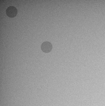

[figure not shown]

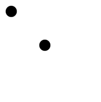

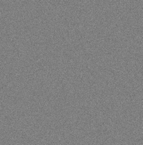

### Appraoch

- Robust regularlized SVD (RobRSVD; [Zhang et al. 2013](http://projecteuclid.org/euclid.aoas/1380804806)) is used to estiamte background
- A sparse modification of RobRSVD is used to estimate foreground
- The degree of smoothness is automatically chosen via GCV
- The [`RobRSVD`](https://cran.r-project.org/web/packages/RobRSVD/index.html) R library implements standard RobRSVD in pure R
- We translated the `RobRSVD` package into C++ and added the option to sparseify

### Example

- Synthetic data example from [Vo and Park (2017)](https://arxiv.org/abs/1609.08078)

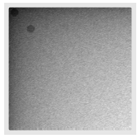

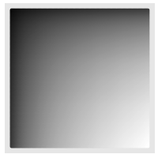

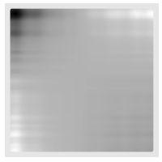

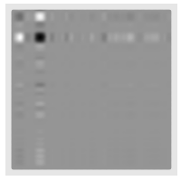

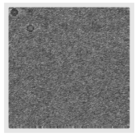

### Real data example

- Real data is much messier
- Consider nucleation data from Abellan et al.

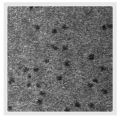

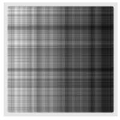

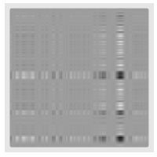

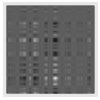

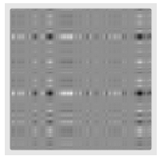

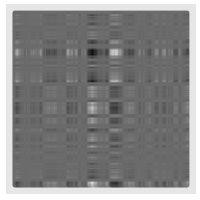

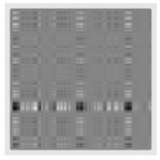

[figure not shown]

### Issue 1: Anode

- Doesn't generalize well to anode videos.

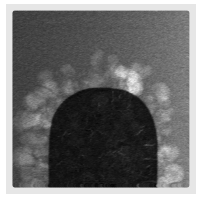

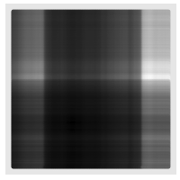

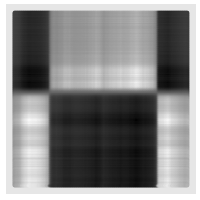

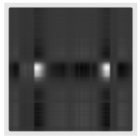

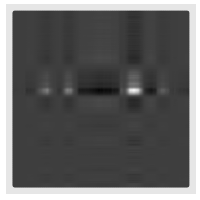

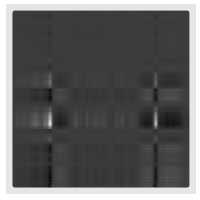

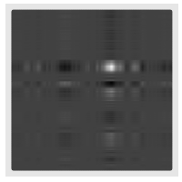

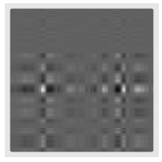

### Issue 2: Missing Data

- Doesn't perform well when data are missing (75% missing here)

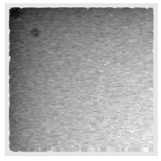

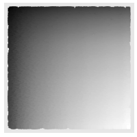

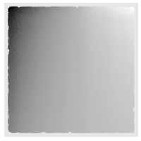

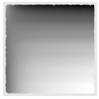

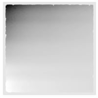

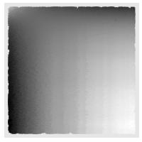